# 520397297 Assignment1 implementation

## Data processing

```python
import pandas as pd
import numpy as np
import matplotlib.pyplot as plt
import seaborn as sns
```

```python
data=pd.read_csv('HeatingLoad_training.csv')
data.index = pd.Index(range(1, len(data) + 1))
data.head()
```

|  | BuildingAge | BuildingHeight | Insulation | AverageTemperature | SunlightExposure | WindSpeed | OccupancyRate | HeatingLoad |
| --- | --- | --- | --- | --- | --- | --- | --- | --- |
| 1 | 18.56 | 30.36 | 1 | 13.75 | 453.67 | 3.89 | 0.65 | 275.89 |
| 2 | 13.82 | 9.64 | 0 | 18.70 | 138.85 | 0.95 | 0.55 | 208.02 |
| 3 | 36.47 | 8.44 | 1 | 18.23 | 190.31 | 4.71 | 0.56 | 234.86 |
| 4 | 23.23 | 18.71 | 1 | 21.89 | 313.15 | 8.51 | 0.25 | 243.89 |
| 5 | 11.62 | 11.95 | 0 | 19.49 | 117.53 | 1.57 | 0.58 | 205.94 |

## Training and validation sets

```python
# splitting the data into training (70%) and validation (30%) sets
train = data.sample(frac=0.7, random_state=1)
validation = data[~data.index.isin(train.index)].copy()

train.head()
```

|  | BuildingAge | BuildingHeight | Insulation | AverageTemperature | SunlightExposure | WindSpeed | OccupancyRate | HeatingLoad |
| --- | --- | --- | --- | --- | --- | --- | --- | --- |
| 9954 | 27.45 | 54.63 | 0 | 15.16 | 38.87 | 1.52 | 0.28 | 418.37 |
| 3851 | 8.53 | 6.34 | 1 | 18.57 | 79.57 | 4.88 | 0.46 | 198.62 |
| 4963 | 40.88 | 12.16 | 0 | 18.31 | 78.24 | 3.24 | 0.46 | 250.11 |
| 3887 | 30.93 | 45.80 | 1 | 19.69 | 84.64 | 1.30 | 0.50 | 363.98 |
| 5438 | 16.53 | 12.46 | 1 | 18.70 | 232.60 | 2.67 | 0.36 | 214.42 |

## Exploratory data analysis

```python
# perform EDA on the training set
train.info()
summary_stats = train.describe().round(2)
print(summary_stats)
```

```
<class 'pandas.core.frame.DataFrame'>
Int64Index: 7000 entries, 9954 to 5446
Data columns (total 8 columns):
 #   Column              Non-Null Count  Dtype
---  ------              --------------  -----
 0   BuildingAge         7000 non-null   float64
 1   BuildingHeight      7000 non-null   float64
 2   Insulation          7000 non-null   int64
 3   AverageTemperature  7000 non-null   float64
 4   SunlightExposure    7000 non-null   float64
 5   WindSpeed           7000 non-null   float64
 6   OccupancyRate       7000 non-null   float64
 7   HeatingLoad         7000 non-null   float64
dtypes: float64(7), int64(1)
memory usage: 492.2 KB
       BuildingAge  BuildingHeight  Insulation  AverageTemperature  \
count      7000.00         7000.00     7000.00             7000.00
mean         22.73           20.79        0.59               18.04
std          12.42           16.89        0.49                4.09
min           2.99            3.07        0.00                1.68
25%          14.27            9.34        0.00               15.30
50%          20.02           15.12        1.00               18.05
75%          27.95           25.65        1.00               20.79
max         153.88          106.36        1.00               34.34

       SunlightExposure  WindSpeed  OccupancyRate  HeatingLoad
count           7000.00    7000.00        7000.00      7000.00
mean             270.91       4.51           0.50       260.08
std              228.21       2.52           0.22        74.68
min                1.15       0.07           0.01       173.68
25%              100.89       2.65           0.32       218.25
50%              181.80       4.10           0.50       236.94
75%              405.38       5.99           0.67       270.41
max             1250.71      18.91           1.00       793.92
```

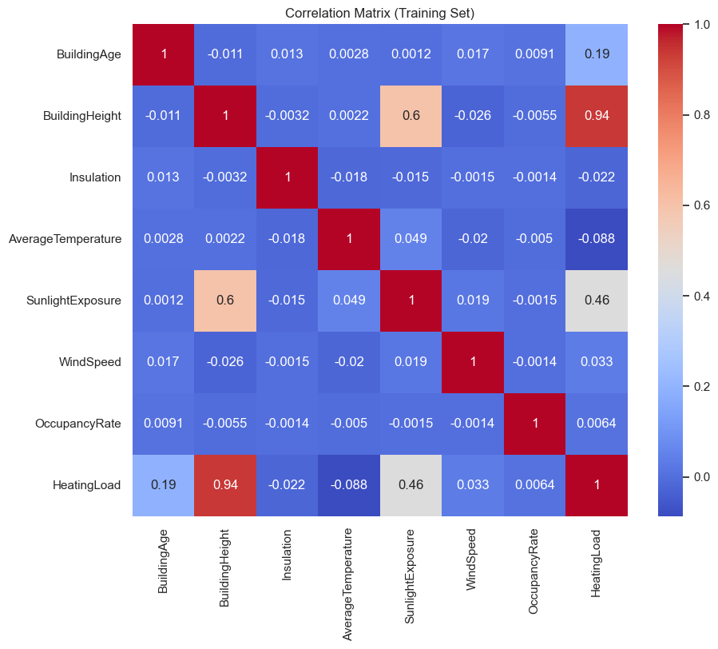

```python
# correlation matrix for the training set
corr_matrix = train.corr()
plt.figure(figsize=(10, 8))
sns.heatmap(corr_matrix, annot=True, cmap="coolwarm")
plt.title("Correlation Matrix (Training Set)")
plt.savefig('Correlation Matrix.png')
plt.show()
```

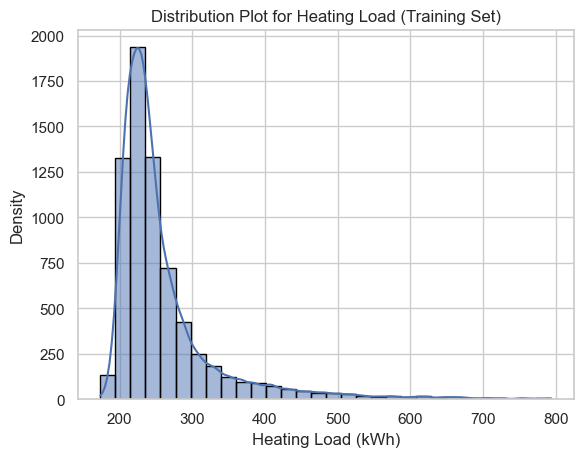

```python
# histogram with KDE for HeatingLoad
fig, ax = plt.subplots()
sns.histplot(train['HeatingLoad'], ax=ax, bins=30, kde=True,
             edgecolor='black', kde_kws={'bw_adjust': 0.5})
ax.set_title('Distribution Plot for Heating Load (Training Set)')
plt.xlabel('Heating Load (kWh)')
plt.ylabel('Density')
plt.show()
```

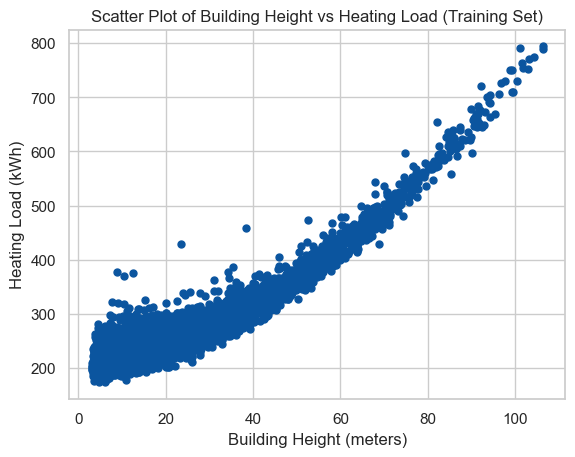

```python
# scatter plot for Building Height vs Heating Load
fig, ax = plt.subplots()
plt.scatter(train['BuildingHeight'], train['HeatingLoad'], color=blue, s=25)
ax.set_xlabel('Building Height (meters)')
ax.set_ylabel('Heating Load (kWh)')
plt.title('Scatter Plot of Building Height vs Heating Load (Training Set)')
plt.show()
```

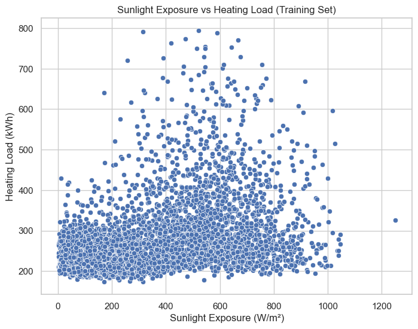

```python
# scatter plot for Sunlight Exposure vs Heating Load
plt.figure(figsize=(8,6))
sns.scatterplot(x=train['SunlightExposure'], y=train['HeatingLoad'])
plt.title('Sunlight Exposure vs Heating Load (Training Set)')
plt.xlabel('Sunlight Exposure (W/m²)')
plt.ylabel('Heating Load (kWh)')
plt.show()
```

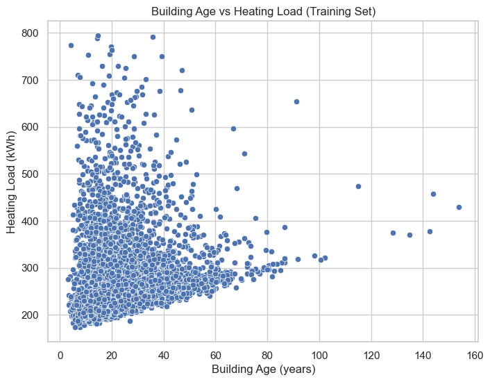

```python
# scatter plot for Building Age vs Heating Load
plt.figure(figsize=(8,6))
sns.scatterplot(x=train['BuildingAge'], y=train['HeatingLoad'])
plt.title('Building Age vs Heating Load (Training Set)')
plt.xlabel('Building Age (years)')
plt.ylabel('Heating Load (kWh)')
plt.show()
```

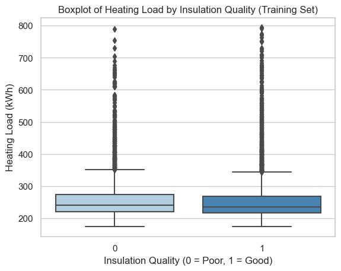

```python
# boxplot of HeatingLoad by Insulation Quality
fig, ax = plt.subplots()
sns.boxplot(x=train['Insulation'], y=train['HeatingLoad'], palette='Blues')
ax.set_title('Boxplot of Heating Load by Insulation Quality (Training Set)')
plt.xlabel('Insulation Quality (0 = Poor, 1 = Good)')
plt.ylabel('Heating Load (kWh)')
plt.show()
```

## KNN regression performance

### knn regession preformance with only 'BuildingHeight' predictor since it has the most correlation with 'HeatingLoad'

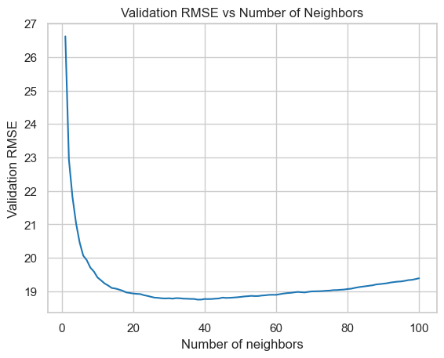

```
Lowest validation RMSE: K = 38
```

```python
from sklearn.neighbors import KNeighborsRegressor
from sklearn.metrics import mean_squared_error

most_correlated_feature = 'BuildingHeight'

# define the range of neighbors to test
neighbors = np.arange(1, 101)
validation_rmse = []

# loop over different values of k for cross-validation
for k in neighbors:
    knn = KNeighborsRegressor(n_neighbors=k)
    knn.fit(train[[most_correlated_feature]], train['HeatingLoad'])
    predictions = knn.predict(validation[[most_correlated_feature]])
    rmse = np.sqrt(mean_squared_error(validation['HeatingLoad'], predictions))
    validation_rmse.append(rmse)

# plot the validation RMSE vs number of neighbors
fig, ax = plt.subplots()
ax.plot(neighbors, validation_rmse, color='#1F77B4')
ax.set_xlabel('Number of neighbors')
ax.set_ylabel('Validation RMSE')
plt.title('Validation RMSE vs Number of Neighbors')
plt.show()

best_k = 1 + np.argmin(validation_rmse)
print(f'Lowest validation RMSE: K = {best_k}')
```

### knn regression preformance with 'BuildingHeight' and 'SunlightExposure' as predictors.

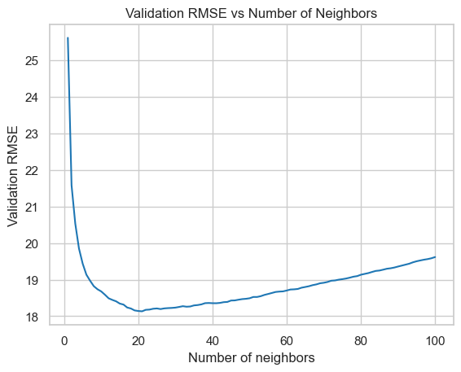

```
Lowest validation RMSE: K = 21
```

```python
predictors = ['BuildingHeight', 'SunlightExposure']

neighbors = np.arange(1, 101)
validation_rmse = []

for k in neighbors:
    knn = KNeighborsRegressor(n_neighbors=k, metric='mahalanobis', metric_params={'V': train[predictors].cov()})
    knn.fit(train[predictors], train['HeatingLoad'])
    predictions = knn.predict(validation[predictors])
    rmse = np.sqrt(mean_squared_error(validation['HeatingLoad'], predictions))
    validation_rmse.append(rmse)

fig, ax = plt.subplots()
ax.plot(neighbors, validation_rmse, color='#1F77B4')
ax.set_xlabel('Number of neighbors')
ax.set_ylabel('Validation RMSE')
plt.title('Validation RMSE vs Number of Neighbors')
plt.show()

best_k = 1 + np.argmin(validation_rmse)
print(f'Lowest validation RMSE: K = {best_k}')
```

### CV with 'BuildingHeight' as predcitor

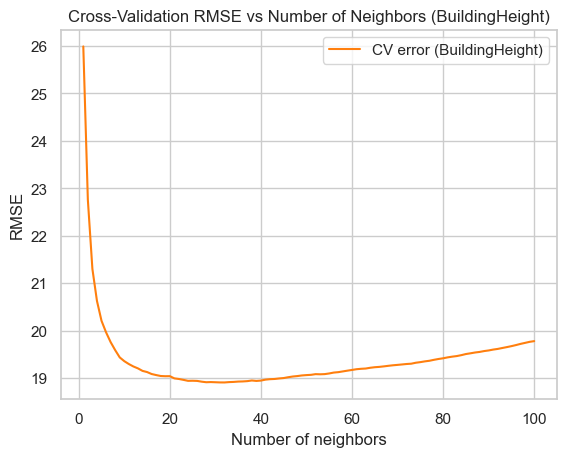

```
Lowest CV error with only BuildingHeight as predictor: K = 32
```

```python
from sklearn.model_selection import KFold, cross_val_score

predictor = ['BuildingHeight']

# create 10 folds cross-validation iterator
kf = KFold(n_splits=10, shuffle=False)
# define the range of neighbors to test
neighbors = np.arange(1, 101)
cv_rmse = []

for k in neighbors:
    knn = KNeighborsRegressor(n_neighbors=k)
    scores = cross_val_score(knn, train[predictor], train['HeatingLoad'], cv=kf, scoring='neg_mean_squared_error')
    rmse = np.sqrt(-1 * np.mean(scores))
    cv_rmse.append(rmse)

# plot the cross-validation RMSE vs number of neighbors
fig, ax = plt.subplots()
ax.plot(neighbors, cv_rmse, color='#FF7F0E', label='CV error (BuildingHeight)')
ax.set_xlabel('Number of neighbors')
ax.set_ylabel('RMSE')
ax.set_title('Cross-Validation RMSE vs Number of Neighbors (BuildingHeight)')
plt.legend()
plt.show()

best_k = 1 + np.argmin(cv_rmse)
print(f'Lowest CV error with only BuildingHeight as predictor: K = {best_k}')
```

```python
# train the KNN model on the training set
knn = KNeighborsRegressor(n_neighbors=best_k)
knn.fit(train[predictor], train['HeatingLoad'])

# predict on the validation set
validation_predictions = knn.predict(validation[predictor])

validation_rmse = np.sqrt(mean_squared_error(validation['HeatingLoad'], validation_predictions))
print(f'Validation RMSE with best K={best_k}: {validation_rmse}')
```

```
Validation RMSE with best K=32: 18.79147085076082
```

### Adding predictors

```python
train.corr().round(3)['HeatingLoad']
```

```
BuildingAge           0.195
BuildingHeight        0.937
Insulation           -0.022
AverageTemperature   -0.088
SunlightExposure      0.456
WindSpeed             0.033
OccupancyRate         0.006
HeatingLoad           1.000
Name: HeatingLoad, dtype: float64
```

```python
# function to perform KNN with Mahalanobis distance and cross-validation
def knn_test(predictors, response):

    neighbours=np.arange(1, 51)
    best_score = -np.inf

    for k in neighbours:
        knn = KNeighborsRegressor(n_neighbors = k, metric='mahalanobis', metric_params={'V': train[predictors].cov()})
        scores = cross_val_score(knn, train[predictors], train[response], cv=10, scoring = 'neg_mean_squared_error')
        # taking the average of scores across 10 folds
        cv_score = np.mean(scores)
        # use the cv score for model selection
        if cv_score >= best_score:
            best_score = cv_score
            best_knn = knn

    knn = best_knn
    # train the selected model with the whole train set
    knn.fit(train[predictors], train[response])
    # Predict the test data with the selected and re-estimated model
    predictions = knn.predict(validation[predictors])
    validation_rmse = np.sqrt(mean_squared_error(validation[response], predictions))
    cv_rmse= np.sqrt(-best_score)
    print('Chosen K: {}'.format(knn.n_neighbors))

    return validation_rmse, cv_rmse
```

```python
response='HeatingLoad'
predictors=['BuildingHeight', 'SunlightExposure']
validation_rmse, cv_rmse  =  knn_test(predictors, response)
print('Validation RMSE : {}'.format(validation_rmse.round(2)))
print('Cross validation RMSE : {}'.format(cv_rmse.round(2)))
```

```
Chosen K: 26
Validation RMSE : 18.19
Cross validation RMSE : 18.56
```

```python
response='HeatingLoad'
predictors=['BuildingHeight', 'SunlightExposure', 'BuildingAge']
validation_rmse, cv_rmse  =  knn_test(predictors, response)
print('Validation RMSE : {}'.format(validation_rmse.round(2)))
print('Cross validation RMSE : {}'.format(cv_rmse.round(2)))
```

```
Chosen K: 8
Validation RMSE : 11.5
Cross validation RMSE : 10.63
```

```python
response='HeatingLoad'
predictors = ['BuildingAge', 'BuildingHeight', 'Insulation', 'AverageTemperature', 'SunlightExposure', 'WindSpeed', 'OccupancyRate']
validation_rmse, cv_rmse  =  knn_test(predictors, response)
print('Validation RMSE : {}'.format(validation_rmse.round(2)))
print('Cross validation RMSE : {}'.format(cv_rmse.round(2)))
```

```
Chosen K: 7
Validation RMSE : 16.82
Cross validation RMSE : 15.66
```

## Select k in KNN with GridSearchCV

`GridSearchCV` is an exhaustive search over specified hyperparameter values, which is convenient when you have a few hyperparameters to search for the best combination. In KNN, there is only one hyperparameter, which is `k`.

```python
predictor_sets = [
    ['BuildingHeight'],
    ['BuildingHeight', 'SunlightExposure'],
    ['BuildingHeight', 'SunlightExposure', 'BuildingAge'],
    ['BuildingAge', 'Insulation'],
    ['BuildingAge', 'BuildingHeight', 'Insulation', 'AverageTemperature', 'SunlightExposure', 'WindSpeed', 'OccupancyRate']
]

# range of neighbors to test
param_grid = {'n_neighbors': np.arange(1, 51)}

for predictors in predictor_sets:
    print(f"Running GridSearchCV for predictors: {predictors}")
    knn = KNeighborsRegressor()
# set up GridSearchCV
    grid_search = GridSearchCV(knn, param_grid, cv=10, scoring='neg_mean_squared_error', verbose=1)
# fit the model using GridSearchCV
    grid_search.fit(train[predictors], train['HeatingLoad'])

# get the best model and parameters
    best_k = grid_search.best_params_['n_neighbors']
    best_score = grid_search.best_score_
    print(f'Best k: {best_k}')
    print(f'Best score (neg MSE): {best_score}')

# evaluate on the test set
    best_knn = grid_search.best_estimator_
    validation_predictions = best_knn.predict(validation[predictors])
    validation_rmse = np.sqrt(mean_squared_error(validation['HeatingLoad'], validation_predictions))
    print(f'Validation RMSE: {validation_rmse}\n')
```

```
Running GridSearchCV for predictors: ['BuildingHeight']
Fitting 10 folds for each of 50 candidates, totalling 500 fits
Best k: 32
Best score (neg MSE): -357.4096074618443
Validation RMSE: 18.79147085076082

Running GridSearchCV for predictors: ['BuildingHeight', 'SunlightExposure']
Fitting 10 folds for each of 50 candidates, totalling 500 fits
Best k: 5
Best score (neg MSE): -485.78404822057144
Validation RMSE: 21.37368706963463

Running GridSearchCV for predictors: ['BuildingHeight', 'SunlightExposure', 'BuildingAge']
Fitting 10 folds for each of 50 candidates, totalling 500 fits
Best k: 3
Best score (neg MSE): -259.15893696825395
Validation RMSE: 16.28761716355915

Running GridSearchCV for predictors: ['BuildingAge', 'Insulation']
Fitting 10 folds for each of 50 candidates, totalling 500 fits
Best k: 50
Best score (neg MSE): -5484.578836994314
Validation RMSE: 72.80236847537905

Running GridSearchCV for predictors: ['BuildingAge', 'BuildingHeight', 'Insulation', 'AverageTemperature', 'SunlightExposure', 'WindSpeed', 'OccupancyRate']
Fitting 10 folds for each of 50 candidates, totalling 500 fits
Best k: 3
Best score (neg MSE): -215.12192438571424
Validation RMSE: 14.73608915667021
```

## Variable Selection

```python
response = ['HeatingLoad']
predictors = ['BuildingAge', 'BuildingHeight', 'Insulation', 'AverageTemperature',
              'SunlightExposure', 'WindSpeed', 'OccupancyRate']
data = data[response + predictors]
```

```python
predictors
```

```
['BuildingAge',
 'BuildingHeight',
 'Insulation',
 'AverageTemperature',
 'SunlightExposure',
 'WindSpeed',
 'OccupancyRate']
```

### Standardizing the Predictors

```python
mu=train[predictors].mean() # mean for each feature
sigma=train[predictors].std() # std for each feature
```

```python
mu.head()
```

```
BuildingAge            22.733884
BuildingHeight         20.791394
Insulation              0.594714
AverageTemperature     18.042026
SunlightExposure      270.910627
dtype: float64
```

```python
sigma.head()
```

```
BuildingAge            12.416525
BuildingHeight         16.887490
Insulation              0.490982
AverageTemperature      4.085190
SunlightExposure      228.214557
dtype: float64
```

```python
train[predictors]=(train[predictors]-mu)/sigma
validation[predictors]=(validation[predictors]-mu)/sigma
```

Check the means of the predictors (in training data) after standardization. Observe that the data have been centered (i.e. having a zero mean).

```python
train[predictors].mean().head()
```

```
BuildingAge           1.015061e-18
BuildingHeight       -4.669281e-17
Insulation           -5.532083e-17
AverageTemperature    9.490821e-17
SunlightExposure     -4.060244e-17
dtype: float64
```

Check the standard deviations of the predictors (in training data) after standardization.

```python
train[predictors].std().head()
```

```
BuildingAge           1.0
BuildingHeight        1.0
Insulation            1.0
AverageTemperature    1.0
SunlightExposure      1.0
dtype: float64
```

### Generate Polynomial Features

```python
from sklearn.preprocessing import PolynomialFeatures

# generate polynomial features of a specific degree
degree = 2
poly_transformer = PolynomialFeatures(degree=degree)
X_poly_train = poly_transformer.fit_transform(train[predictors])
X_poly_validation = poly_transformer.transform(validation[predictors])
```

### Fit the Polynomial Regression Model

```python
from sklearn.linear_model import LinearRegression

poly_model = LinearRegression()
# fit the model using the polynomial features
poly_model.fit(X_poly_train, train['HeatingLoad'])

# predict on the validation set
y_pred = poly_model.predict(X_poly_validation)
```

### Evaluate the Performance (Using RMSE)

```python
# calculate RMSE for the validation set
rmse = np.sqrt(mean_squared_error(validation['HeatingLoad'], y_pred))
print(f'RMSE for degree {degree}: {rmse}')
```

```
RMSE for degree 2: 1.990360224592735
```

### Cross-validation for polynomial regression to decide the best degree

```python
# different degrees for polynomial regression
degrees = [1, 2, 3, 4, 5]
cv_scores = []

# cv for each degree
for degree in degrees:
    poly_transformer = PolynomialFeatures(degree=degree)
    X_poly_train = poly_transformer.fit_transform(train[predictors])
    lin_reg = LinearRegression()
# 10-fold cross-validation and store neg MSE
    scores = cross_val_score(lin_reg, X_poly_train, train['HeatingLoad'], cv=10, scoring='neg_mean_squared_error')
    cv_scores.append(np.mean(scores))

for degree, score in zip(degrees, cv_scores):
    print(f'Degree {degree}, CV Score (Neg MSE): {score}')
best_degree = degrees[np.argmax(cv_scores)]
print(f'Best degree: {best_degree}')
```

```
Degree 1, CV Score (Neg MSE): -296.63337569101344
Degree 2, CV Score (Neg MSE): -3.9522914075600837
Degree 3, CV Score (Neg MSE): -4.000738138211824
Degree 4, CV Score (Neg MSE): -4.282040491544189
Degree 5, CV Score (Neg MSE): -12.343377197600736
Best degree: 2
```

### Refit the model with the best degree

```python
poly_transformer = PolynomialFeatures(degree=best_degree)
X_poly_train = poly_transformer.fit_transform(train[predictors])
X_poly_validation = poly_transformer.transform(validation[predictors])

best_poly_model = LinearRegression()
best_poly_model.fit(X_poly_train, train['HeatingLoad'])

# make predictions on the validation set
y_best_pred = best_poly_model.predict(X_poly_validation)

# evaluate RMSE
best_rmse = np.sqrt(mean_squared_error(validation['HeatingLoad'], y_best_pred))
print(f'Best RMSE with degree {best_degree} for all variables as predictors: {best_rmse}')
```

```
Best RMSE with degree 2 for all variables as predictors: 1.990360224592735
```

### Polynomial regression with different subset of variables

```python
# subset 1: Polynomial regression on BuildingHeight and SunlightExposure
predictors_subset1 = ['BuildingHeight', 'SunlightExposure']
poly_deg = 2

# polynomial transformation
poly_transformer_1 = PolynomialFeatures(degree=poly_deg)
train_poly_1 = poly_transformer_1.fit_transform(train[predictors_subset1])
validation_poly_1 = poly_transformer_1.transform(validation[predictors_subset1])

# train and predict
poly_model_1 = LinearRegression()
poly_model_1.fit(train_poly_1, train['HeatingLoad'])
validation_predictions_1 = poly_model_1.predict(validation_poly_1)
validation_rmse_1 = np.sqrt(mean_squared_error(validation['HeatingLoad'], validation_predictions_1))

# subset 2: Polynomial regression on BuildingAge and Insulation
predictors_subset2 = ['BuildingAge', 'Insulation']
poly_transformer_2 = PolynomialFeatures(degree=poly_deg)
train_poly_2 = poly_transformer_2.fit_transform(train[predictors_subset2])
validation_poly_2 = poly_transformer_2.transform(validation[predictors_subset2])

poly_model_2 = LinearRegression()
poly_model_2.fit(train_poly_2, train['HeatingLoad'])
validation_predictions_2 = poly_model_2.predict(validation_poly_2)
validation_rmse_2 = np.sqrt(mean_squared_error(validation['HeatingLoad'], validation_predictions_2))

print(f'Validation RMSE for Subset 1 (BuildingHeight & SunlightExposure): {validation_rmse_1}')
print(f'Validation RMSE for Subset 2 (BuildingAge & Insulation): {validation_rmse_2}')
```

```
Validation RMSE for Subset 1 (BuildingHeight & SunlightExposure): 17.50417051097033
Validation RMSE for Subset 2 (BuildingAge & Insulation): 72.31167093287858
```

### Model Selection Using AIC/BIC

```python
# function to calculate sigma2_hat and then AIC and BIC using RMSE
def calculate_aic_bic(n, rmse, p):
    sigma2_hat = rmse ** 2
    aic_value = n * np.log(sigma2_hat) + 2 * p
    bic_value = n * np.log(sigma2_hat) + np.log(n) * p
    return aic_value, bic_value

# function to fit polynomial regression and compute AIC/BIC
def polynomial_regression_with_aic_bic(predictors, degree, train, validation, response_col):
    poly_transformer = PolynomialFeatures(degree=degree)
    X_train_poly = poly_transformer.fit_transform(train[predictors])
    X_validation_poly = poly_transformer.transform(validation[predictors])

    model = LinearRegression()
    model.fit(X_train_poly, train[response_col])

    validation_predictions = model.predict(X_validation_poly)

    # RMSE on validation set
    rmse = np.sqrt(mean_squared_error(validation[response_col], validation_predictions))

    # number of parameters
    p = X_train_poly.shape[1]
    n = len(validation[response_col])

    aic_value, bic_value = calculate_aic_bic(n, rmse, p)

    return aic_value, bic_value, rmse
```

```python
predictors_subset1 = ['BuildingHeight', 'SunlightExposure']
predictors_subset2 = ['BuildingAge', 'Insulation']
predictors_subset3 = ['BuildingHeight', 'SunlightExposure', 'BuildingAge']
predictors_all = ['BuildingAge', 'BuildingHeight', 'Insulation', 'AverageTemperature',
                 'SunlightExposure', 'WindSpeed', 'OccupancyRate']

best_degree = 2

aic_1, bic_1, rmse_1 = polynomial_regression_with_aic_bic(predictors_subset1, best_degree, train, validation, 'HeatingLoad')
aic_2, bic_2, rmse_2 = polynomial_regression_with_aic_bic(predictors_subset2, best_degree, train, validation, 'HeatingLoad')
aic_3, bic_3, rmse_3 = polynomial_regression_with_aic_bic(predictors_subset3, best_degree, train, validation, 'HeatingLoad')
aic_all, bic_all, rmse_all = polynomial_regression_with_aic_bic(predictors_all, best_degree, train, validation, 'HeatingLoad')

print(f'Subset 1 (BuildingHeight & SunlightExposure): AIC = {aic_1}, BIC = {bic_1}, RMSE = {rmse_1}')
print(f'Subset 2 (BuildingAge & Insulation): AIC = {aic_2}, BIC = {bic_2}, RMSE = {rmse_2}')
print(f'Subset 3 (BuildingHeight, SunlightExposure & BuildingAge): AIC = {aic_3}, BIC = {bic_3}, RMSE = {rmse_3}')
print(f'All Variables: AIC = {aic_all}, BIC = {bic_all}, RMSE = {rmse_all}')
```

```
Subset 1 (BuildingHeight & SunlightExposure): AIC = 17186.635004697426, BIC = 17222.673210103327, RMSE = 17.50417051097033
Subset 2 (BuildingAge & Insulation): AIC = 25697.913238971505, BIC = 25733.951444377406, RMSE = 72.31167093287858
Subset 3 (BuildingHeight, SunlightExposure & BuildingAge): AIC = 12698.085405923368, BIC = 12758.14908159987, RMSE = 8.2731409244131
All Variables: AIC = 4201.886676565695, BIC = 4418.115909001103, RMSE = 1.9903578488131448
```

### Variable Selection in OLS

```python
import statsmodels.api as sm

predictors = ['BuildingAge', 'BuildingHeight', 'Insulation', 'AverageTemperature',
              'SunlightExposure', 'WindSpeed', 'OccupancyRate']
response_col = 'HeatingLoad'

# add intercept to predictors
X_train = sm.add_constant(train[predictors], prepend=True)
X_validation = sm.add_constant(validation[predictors], prepend=True)

# fit OLS model
ols_model = sm.OLS(train[response_col], X_train).fit()

print(ols_model.summary())

# predictions on the validation set
validation_predictions = ols_model.predict(X_validation)

# RMSE for the validation set
validation_rmse = np.sqrt(mean_squared_error(validation[response_col], validation_predictions))
print(f'Validation RMSE for all variables subset: {validation_rmse}\n')
```

[output not shown]

```python
# function to fit OLS regression and return the summary
def ols_regression(predictors, train, validation, response_col):
    X_train = sm.add_constant(train[predictors])
    X_validation = sm.add_constant(validation[predictors])
    ols_model = sm.OLS(train[response_col], X_train).fit()
    validation_predictions = ols_model.predict(X_validation)
    validation_rmse = np.sqrt(mean_squared_error(validation[response_col], validation_predictions))
    return ols_model.summary(), validation_rmse
```

```python
# subset 1: BuildingHeight and SunlightExposure
ols_summary_1, ols_rmse_1 = ols_regression(['BuildingHeight', 'SunlightExposure'], train, validation, 'HeatingLoad')

print(f'OLS Summary for Subset 1 (BuildingHeight & SunlightExposure):\n{ols_summary_1}')
print(f'Validation RMSE for Subset 1 (BuildingHeight & SunlightExposure): {ols_rmse_1}\n')
```

[output not shown]

```python
# subset 2: BuildingHeight, SunlightExposure, and BuildingAge
ols_summary_2, ols_rmse_2 = ols_regression(['BuildingHeight', 'SunlightExposure', 'BuildingAge'], train, validation, 'HeatingLoad')

print(f'OLS Summary for Subset 2 (BuildingHeight, SunlightExposure & BuildingAge):\n{ols_summary_2}')
print(f'Validation RMSE for Subset 2 (BuildingHeight, SunlightExposure & BuildingAge): {ols_rmse_2}\n')
```

```
OLS Summary for Subset 2 (BuildingHeight, SunlightExposure & BuildingAge):
                            OLS Regression Results
==============================================================================
Dep. Variable:            HeatingLoad   R-squared:                       0.936
Model:                            OLS   Adj. R-squared:                  0.936
Method:                 Least Squares   F-statistic:                 3.423e+04
Date:                Mon, 16 Sep 2024   Prob (F-statistic):               0.00
Time:                        17:43:26   Log-Likelihood:                -30491.
No. Observations:                7000   AIC:                         6.099e+04
Df Residuals:                    6996   BIC:                         6.102e+04
Df Model:                           3
Covariance Type:            nonrobust
====================================================================================
                       coef    std err          t      P>|t|      [0.025      0.975]
------------------------------------------------------------------------------------
const              260.0814      0.225   1153.544      0.000     259.639     260.523
BuildingHeight      77.4248      0.281    275.169      0.000      76.873      77.976
SunlightExposure   -12.2454      0.281    -43.523      0.000     -12.797     -11.694
BuildingAge         15.3796      0.226     68.202      0.000      14.938      15.822
==============================================================================
Omnibus:                     3088.253   Durbin-Watson:                   2.022
Prob(Omnibus):                  0.000   Jarque-Bera (JB):            33935.390
Skew:                           1.817   Prob(JB):                         0.00
Kurtosis:                      13.156   Cond. No.                         1.99
==============================================================================

Notes:
[1] Standard Errors assume that the covariance matrix of the errors is correctly specified.
Validation RMSE for Subset 2 (BuildingHeight, SunlightExposure & BuildingAge): 17.79923216689189
```

### Search for Alpha

```python
from sklearn.linear_model import LassoCV

# define a wide range of alpha values
alphas_coarse = np.logspace(-3, 3, 50)

# initialize the LassoCV model with the coarse range of alphas
lasso_cv_coarse = LassoCV(alphas=alphas_coarse, cv=10, max_iter=10000)

# fit the model on the training data
lasso_cv_coarse.fit(train[predictors], train[response_col])

# best alpha
best_alpha_coarse = lasso_cv_coarse.alpha_
print(f'Best alpha: {best_alpha_coarse}')

# coefficients for the best alpha
lasso_coefficients_coarse = lasso_cv_coarse.coef_
print("Lasso Coefficients with Best Alpha:")
for feature, coef in zip(predictors, lasso_coefficients_coarse):
    print(f"{feature}: {coef}")

# predict on the validation set
lasso_validation_predictions_coarse = lasso_cv_coarse.predict(validation[predictors])
# RMSE
lasso_validation_rmse_coarse = np.sqrt(mean_squared_error(validation[response_col], lasso_validation_predictions_coarse))
print(f'Validation RMSE for Lasso with best alpha: {lasso_validation_rmse_coarse}')
```

[output not shown]

### Ridge regression

```python
from sklearn.linear_model import RidgeCV

ridge_alphas = np.logspace(-4, 1, 100)

# cvfor Ridge regression
ridge_cv = RidgeCV(alphas=ridge_alphas, cv=10)
ridge_cv.fit(train[predictors], train[response])

# predict on validation set
validation_predictions_ridge = ridge_cv.predict(validation[predictors])

# RMSE
ridge_rmse = np.sqrt(mean_squared_error(validation[response], validation_predictions_ridge))
print(f"Validation RMSE for Ridge: {ridge_rmse}")
print(f"Best alpha for Ridge: {ridge_cv.alpha_}")
```

```
Validation RMSE for Ridge: 16.35056094733991
Best alpha for Ridge: 10.0
```

### Finding the best alpha

```python
lasso = LassoCV(cv=10)
lasso.fit(train[predictors], np.ravel(train[response])) # the np.ravel is a necessary detail for compatibility
```

```
LassoCV(cv=10)
```

```python
print("LASSO Lambda: {0}".format(lasso.alpha_))
```

```
LASSO Lambda: 0.06992746215417227
```

```python
pd.DataFrame(lasso.coef_.round(3), index = predictors).T
```

|  | BuildingAge | BuildingHeight | Insulation | AverageTemperature | SunlightExposure | WindSpeed | OccupancyRate |
| --- | --- | --- | --- | --- | --- | --- | --- |
| 0 | 15.271 | 77.256 | -1.781 | -6.064 | -11.883 | 4.232 | 0.645 |

Variables that could be considered for removal:

OccupancyRate: The coefficient is very small (0.65), suggesting that this variable has little influence on the target variable. It might not contribute much to the model.

Insulation: Although this coefficient is negative (-1.78), it is also relatively small in magnitude. Could consider its removal, especially if interpretability or simplicity is a priority.

### Refit the OLS model

```python
selected_predictors = ['BuildingAge', 'BuildingHeight', 'AverageTemperature', 'SunlightExposure', 'WindSpeed']

# refit OLS model using only the selected predictors
x_with_intercept = sm.add_constant(train[selected_predictors], prepend=True)
ols = sm.OLS(train[response],x_with_intercept)
est = ols.fit()
print(est.summary())
```

[output not shown]

```python
final_model = LinearRegression()
final_model.fit(train[selected_predictors], train[response])

validation_predictions = final_model.predict(validation[selected_predictors])

validation_rmse = np.sqrt(mean_squared_error(validation[response], validation_predictions))
print(f"Validation RMSE: {validation_rmse}")
```

```
Validation RMSE: 16.45020884252283
```